# Calculate perturbation scores for Perturb-seq data

Longda Jiang

2023-09-12

## Introduction

This html file describes a robust computational framework, “perturbation scoring”, that allows us to accurately and efficiently capture the wide range of cellular responses to different perturbations in the context of single-cell pooled CRSIPR screens. Instead of treating cells that receive the same gRNA equally, this framework uses a scoring strategy (extended from ‘mixscape’, see https://satijalab.org/seurat/articles/mixscape_vignette) to capture the variability in each cell’s response to the perturbation. Specifically, we introduce functions for:  
1. calculating ‘perturbation scores’ for cells that receives the same perturbation across multiple cell lines  
2. performing scoring-based differential expression (DE) tests to identify DE genes for different perturbations  
3. performing different levels of decomposition analysis to identify correlated perturbations given their shared DE genes  
4. performing PCA-based permutation tests to identify shared gene signatures for correlation perturbations  
5. constructing a gene-set repository for each group of correlated perturbations (similar to a gene-ontology database)  
5. performing enrichment tests for external gene lists using the gene-set repo generated above

## load the packages

```r
library(devtools)
library(Seurat)
library(ggridges)
library(PRTBScoring)
```

## 0. load the demo data

The demo dataset contains CRISPRi Perturb-seq data for the IFN-gamma pathway. The perturbation targets include “IFNGR1”, “IRF1”, “IRF2”, “JAK1”, “STAT1”, etc..

```r
seurat_obj = readRDS(file = "/Users/uqljian5/Desktop/Lab_stuffs_NYGC/raw_seq_processing_2021Dec/mixscape_dat10x_NovaSeq_2021Dec07.rds")
seurat_obj$cell_type = seurat_obj$HTO_classification
seurat_obj$cell_type[seurat_obj$cell_type == "Negative"] = "K562"
DefaultAssay(seurat_obj) = "RNA"
seurat_obj[['PRTB']] = NULL

# select a subset of perturbations for our demo
# the perturbation identity is stored in the "gene" column in the meta.data
seurat_obj = subset(seurat_obj, subset = gene %in% c("NT", "ZC3H3", "IFNGR1", "IFNGR2",
                                                     "IRF1", "IRF2", "IRF5", "JUN", "MAFF",
                                                     "PARP12", "RUNX1",
                                                     "JAK1", "JAK2",
                                                     "STAT1", "STAT2", "STAT3"))
table(seurat_obj$gene, seurat_obj$cell_type)
```

```
##
##          A549 BXCP3 HAP1 HT29 K562 MCF7 THP1
##   IFNGR1  122    51   39  104  108   60   93
##   IFNGR2  189   135  124  181  206  150  140
##   IRF1    184    74   79  170  257  133  131
##   IRF2     43     6   14   27   55   33   34
##   IRF5    107    38  119  106  151  119   94
##   JAK1    157    83   97  131  188  113  112
##   JAK2    102    14   22   38   64   87   73
##   JUN      63    66   72   58  112   66   62
##   MAFF     93    40  103  111  155   71   75
##   NT      227   157  152  284  355  120  197
##   PARP12  176   102   68  143  253   99  151
##   RUNX1   146   106  137  141  207  105  126
##   STAT1   102    90  135  160  242   88  128
##   STAT2    48     3   18   36   72   28   25
##   STAT3    81    36   55   81  112   39   55
##   ZC3H3    84    63   20   90   47   46   17
```

## 1. Standard processing

To perform standard processing for the dataset.

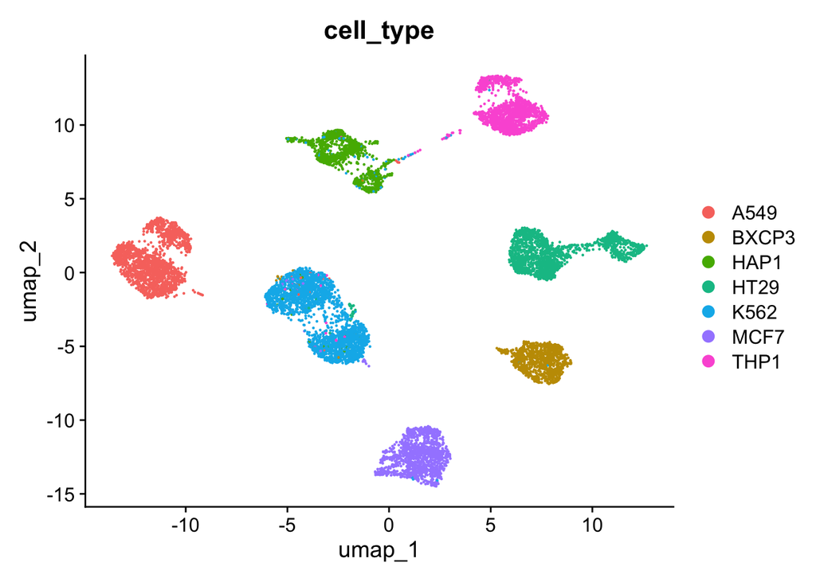

```r
seurat_obj = NormalizeData(seurat_obj)
seurat_obj = FindVariableFeatures(seurat_obj)
seurat_obj = ScaleData(seurat_obj)
seurat_obj = RunPCA(seurat_obj)
seurat_obj = RunUMAP(seurat_obj, dims = 1:40)
DimPlot(seurat_obj, group.by = "cell_type")
```

## 2. Calculate perturbation signatures (correcting for confounding)

To use the CalcPerturbSig() function from “Mixscape” to correct for confounding factors in each cell.

```r
seurat_obj <- CalcPerturbSig(
    object = seurat_obj,
    assay = "RNA",
    slot = "data",
    gd.class ="gene",
    nt.cell.class = "NT",
    reduction = "pca",
    ndims = 40,
    num.neighbors = 20,
    new.assay.name = "PRTB",
    split.by = "cell_type")
```

## 3. Perturbation scoring

This part will use the scoring strategy to assign a score to each cell. The score represents the perturbation strength each cell undergoes.

```r
seurat_obj = PRTBScoring(
    object = seurat_obj,
    assay = "PRTB",
    slot = "scale.data",
    labels = "gene",
    nt.class.name = "NT",
    min.de.genes = 5,
    split.by = "cell_type",
    logfc.threshold = 0.2,
    de.assay = "RNA",
    max.de.genes = 100,
    prtb.type = "P",
    new.class.name = "mixscape_v1",
    fine.mode = F,
    harmonize = T,
    seed = 1)
```

```
## [1] "Running PRTBScoring to calculate the perturbation scores \n"
## [1] "The number of de.genes ( 2 ) is less than max.de.genes ( 100 )."
## [1] "Done with extracting top DE genes for IRF2"
## [1] "The number of de.genes ( 105 ) is larger than max.de.genes ( 100 ). Restricting to top 100 genes..."
## [1] "Done with extracting top DE genes for ZC3H3"
## [1] "The number of de.genes ( 323 ) is larger than max.de.genes ( 100 ). Restricting to top 100 genes..."
## [1] "Done with extracting top DE genes for IFNGR2"
## [1] "The number of de.genes ( 191 ) is larger than max.de.genes ( 100 ). Restricting to top 100 genes..."
## [1] "Done with extracting top DE genes for STAT1"
## [1] "The number of de.genes ( 0 ) is less than max.de.genes ( 100 )."
## [1] "Done with extracting top DE genes for RUNX1"
## [1] "The number of de.genes ( 0 ) is less than max.de.genes ( 100 )."
## [1] "Done with extracting top DE genes for IRF5"
## [1] "The number of de.genes ( 2 ) is less than max.de.genes ( 100 )."
## [1] "Done with extracting top DE genes for PARP12"
```

[output cut: 24 more lines]

```r
# take a look at the scores
Tool(seurat_obj, slot = "PRTBScoring")[[1]][[1]][1:5, 1:2]
```

```
##                        pvec  gene
## AAACGCTAGCGATGGT  0.9558206 STAT1
## AAAGAACGTATGTCTG  0.9532298 STAT1
## AAAGAACGTTGATCGT -0.2742651 STAT1
## AAAGGATGTCAGTTTG  0.7467443 STAT1
## AACAACCAGTGCCGAA -0.4068864 STAT1
```

## 3.5 Some visualizations for the scores

We will now use some plotting functions to explore the perturbation scores that we just calculated.

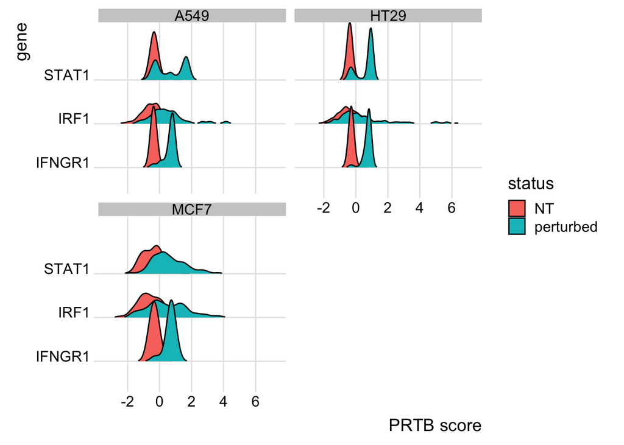

```r
# a. Check the distribution of the scores
PRTBscore_RidgePlot(object = seurat_obj, split.by = "cell_type",
                    PRTB = c("IFNGR1", "IRF1", "STAT1"),
                    facet_wrap = "gene", facet_scale = "fixed",
                    slct_split.by = c("A549", "HT29", "MCF7"),
                    facet_nrow = 2)
```

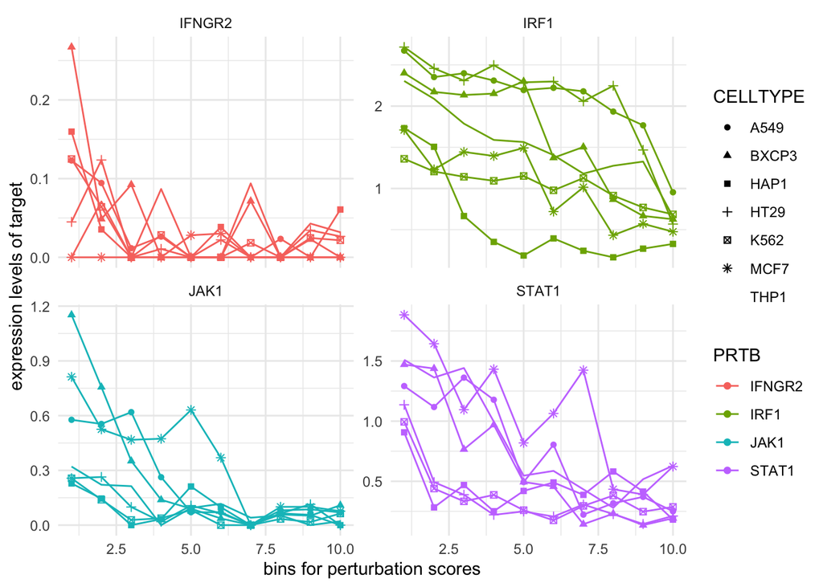

```r
# b. Check if the scores correlate with the expression level of the target gene itself
PRTBscore_ScatterPlot(object = seurat_obj, split.by = "cell_type",
                      PRTB = c("IFNGR2", "JAK1", "IRF1", "STAT1"),
                      facet_wrap = "gene", facet_scale = "free_y")
```

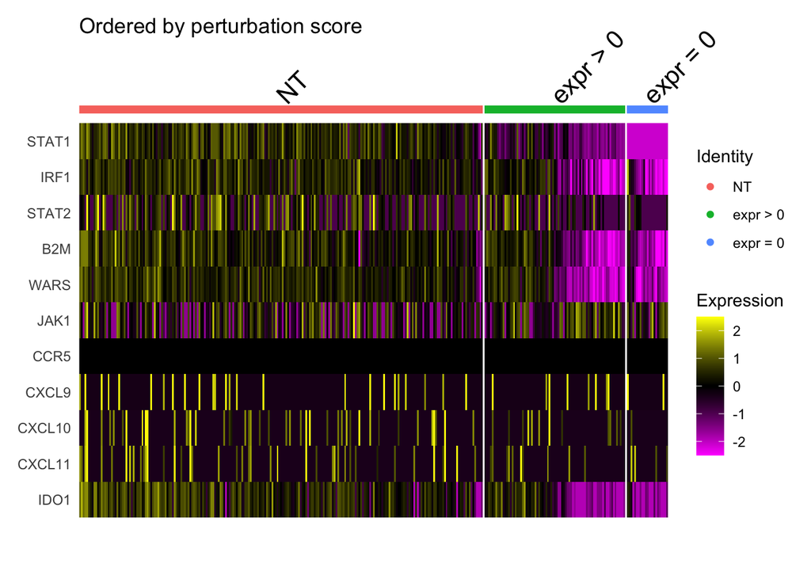

```r
# c. Check the single-cell heatmap (stratified by the expression level of the target genes)
PRTBscore_DoHeatmap(object = seurat_obj, PRTB = "STAT1", slct_condition = "A549",
                    slct_features = c("IRF1",  "STAT2",  "B2M", "WARS", "JAK1",
                                      "CCR5", "CXCL9", "CXCL10", "CXCL11", "IDO1"))
```

## 4. Perform scoring-based DE test

This step will incorporate the scores we just calculated and use them in the differential expression tests. By using the scores as a ‘weight’ for the perturbed cells (instead of universally coding them as 1), we can achieve a higher statistical power.

```r
de_res = scoringDE(object = seurat_obj, assay = "RNA", slot = "counts",
                   PRTB_list = c("RFX5", "ZC3H3", "IFNGR1", "IFNGR2",
                                 "IRF1", "IRF2",  "JUN", "MAFF",
                                 "PARP12", "TRAFD1",
                                 "JAK1",
                                 "STAT1", "SP100"),
                   labels = "gene")
```

```
## [1] "Running scoring DE test!\n"
## [1] "IFNGR1 is running weighted DE test! "
## [1] "DE test for 'IFNGR1' is completed. Number of remaining = 9"
## [1] "IFNGR2 is running weighted DE test! "
## [1] "DE test for 'IFNGR2' is completed. Number of remaining = 8"
## [1] "IRF1 is running weighted DE test! "
## [1] "DE test for 'IRF1' is completed. Number of remaining = 7"
## [1] "IRF2 does not have score. Will use 0/1 for coding."
## [1] "IRF2 is running standard DE test! "
## [1] "DE test for 'IRF2' is completed. Number of remaining = 6"
## [1] "JAK1 is running weighted DE test! "
## [1] "DE test for 'JAK1' is completed. Number of remaining = 5"
## [1] "JUN does not have score. Will use 0/1 for coding."
## [1] "JUN is running standard DE test! "
## [1] "DE test for 'JUN' is completed. Number of remaining = 4"
## [1] "MAFF does not have score. Will use 0/1 for coding."
## [1] "MAFF is running standard DE test! "
## [1] "DE test for 'MAFF' is completed. Number of remaining = 3"
## [1] "PARP12 does not have score. Will use 0/1 for coding."
## [1] "PARP12 is running standard DE test! "
## [1] "DE test for 'PARP12' is completed. Number of remaining = 2"
## [1] "STAT1 is running weighted DE test! "
## [1] "DE test for 'STAT1' is completed. Number of remaining = 1"
## [1] "ZC3H3 is running weighted DE test! "
## [1] "DE test for 'ZC3H3' is completed. Number of remaining = 0"
```

```r
# have a quick look at the DE results
head(de_res[[1]][order(de_res[[1]][, 24]), c(23:31)])
```

```
##          p_log_ct p_cell_typeA549:weight p_cell_typeBXCP3:weight
## 11   0.000000e+00          1.273815e-248            7.235463e-85
## 15  1.029983e-202          1.390434e-205            1.531386e-67
## 14  2.630596e-129          1.156210e-165            6.289691e-53
## 138 5.086373e-104          6.349965e-155            5.612725e-11
## 13   0.000000e+00          2.443793e-135            1.143373e-50
## 111 1.795867e-229          1.195666e-128            3.943414e-15
##     p_cell_typeHAP1:weight p_cell_typeHT29:weight p_cell_typeK562:weight
## 11            9.067353e-78          4.444882e-271           2.774177e-91
## 15            6.085175e-48          9.301025e-139           4.590268e-28
## 14            1.601762e-20          3.531550e-142           1.055104e-45
## 138           1.093122e-02           1.082620e-81           1.110526e-01
## 13            1.907803e-32           1.314658e-92           2.534736e-73
## 111           4.147267e-31           2.465892e-93           4.430731e-06
##     p_cell_typeMCF7:weight p_cell_typeTHP1:weight gene_ID
## 11           3.251721e-119           1.420360e-42     B2M
## 15            2.959377e-19           3.590392e-58    WARS
## 14            9.524447e-33           1.337297e-43    IRF1
## 138           1.204000e-07           9.621607e-22  RNF213
## 13            5.949859e-60           1.137554e-34   PSME2
## 111           3.098968e-03           1.068361e-59    LAP3
```

```r
# re-arrange the results into a list of DE Z-score matrices, removing non-significant DE genes.
# the function will summarize the number of significant DE genes in the screen output.
DEG_mat_main = get_DE_mat(de_res, p_threshold = 0.05/30000, fc_threshold = 0.2)
```

```
## [1] "IFNGR1 : 369"
## [1] "IFNGR2 : 581"
## [1] "IRF1 : 85"
## [1] "IRF2 : 3"
## [1] "JAK1 : 360"
## [1] "JUN : 10"
## [1] "MAFF : 12"
## [1] "PARP12 : 7"
## [1] "STAT1 : 377"
## [1] "ZC3H3 : 128"
```

## 5. Decomposition

In this section we will perform a series of decomposition analyses for our DE results. We will also perform PCA-based permutation tests to extract the gene signatures for the correlated perturbations. We will then aggregate all the gene signatures and arrange them into a repository of different sets of gene signatures.

### 5.1 within perturbation decomposition

```r
# an empty list to store all the gene sets (a repository of gene sets)
go_db = list()

# 5.1 within-prtb decomposition
# to slightly clean up the matrices before decomposition
DEG_mat = prune_DE_mat(DEG_mat_main, mask_target = T, min_sig_DEG = 0)

celltype_list = names(DEG_mat)
PRTB_list = colnames(DEG_mat[[1]])
gene_ID = rownames(DEG_mat[[1]])

# loop through all the perturbations in our dataset
for(i in 1:length(PRTB_list)){
    PRTB = PRTB_list[i]

    tmp=list()
    for(CELLTYPE in celltype_list){
        if(PRTB %in% colnames(DEG_mat[[CELLTYPE]])){
            tmp[[CELLTYPE]] = DEG_mat[[CELLTYPE]][, PRTB]
        }
    }
    tmp = Reduce(cbind, tmp)
    colnames(tmp) = celltype_list
    rownames(tmp) = gene_ID

    #  run Permutation test and extract gene signatures
    #  before each permutation test, PCApermtest() will further filter the
    #  sub-matrix by removing any row (gene) without raw DE P-value <= 0.05 in any column (perturbation).
    res = PCApermtest(mat = tmp, row_filtering_pval = 0.05, k = 1)
    sig_genes = get_sig_genes(perm_obj = res, k = 1, collapse = T)

    ## plot Z-score heatmap for the gene signatures
    ## !!! this is currently commented out, but remove the '#' if you decide to run them
    ##     the figures will be automatically saved to the folder you specify.
    #  DE_heatmap(obj = res, sig_genes = sig_genes, type = "standard", direction = "both", top_n = 30,
    #             output_path = "/Users/uqljian5/Desktop/test_multiCCA/level1/",
    #             prefix = PRTB)

    # store the gene signatures to the go-term repo
    if(length(sig_genes$upDEGs) >= 10){
        go_db[[paste0(PRTB, "_upDEGs")]] = sig_genes$upDEGs
    }
    if(length(sig_genes$downDEGs) >= 10){
        go_db[[paste0(PRTB, "_downDEGs")]] = sig_genes$downDEGs
    }
}
```

```
## [1] "Removing 191 rows given the row_filtering_pval = 0.05"
## [1] "Removing 167 rows given the row_filtering_pval = 0.05"
## [1] "Removing 435 rows given the row_filtering_pval = 0.05"
## [1] "Removing 567 rows given the row_filtering_pval = 0.05"
## [1] "Removing 199 rows given the row_filtering_pval = 0.05"
## [1] "Removing 583 rows given the row_filtering_pval = 0.05"
## [1] "Removing 624 rows given the row_filtering_pval = 0.05"
## [1] "Removing 636 rows given the row_filtering_pval = 0.05"
## [1] "Removing 222 rows given the row_filtering_pval = 0.05"
## [1] "Removing 486 rows given the row_filtering_pval = 0.05"
```

### 5.2 within cell type decomposition

```r
# clean up the matrices
DEG_mat = prune_DE_mat(DEG_mat_main, mask_target = T, min_sig_DEG = 3)

celltype_list = names(DEG_mat)
PRTB_list = colnames(DEG_mat[[1]])
gene_ID = rownames(DEG_mat[[1]])

# loop through all the cell types in our datasets
for(i in 1:length(celltype_list)){
    CELLTYPE = celltype_list[i]
    tmp=DEG_mat[[CELLTYPE]]

    #  run Permutation test and extract gene signatures
    res = DEhclust(mat = tmp)

    # get_sig_genes_DEhclust() is a wrapper function for PCApermtest() and get_sig_genes() for DEhclust object.
    sig_genes = get_sig_genes_DEhclust(obj = res, row_filtering_pval = 0.05)

    ##  plot Z-score heatmap for the gene signatures
    ##  remove the '#' to generate the figures.
    # DE_heatmap(obj = res, sig_genes = sig_genes, type = "hclust", direction = "both", top_n = 30,
    #            output_path = "/Users/uqljian5/Desktop/test_multiCCA/level2/",
    #            prefix = CELLTYPE)

    # store the gene signatures to the go-term repo
    for(CLUSTER in names(sig_genes)){
        if(length(sig_genes[[CLUSTER]]$sig_genes$upDEGs) >= 10){
            go_db[[paste0(CELLTYPE, "_", CLUSTER, "_upDEGs")]] = sig_genes[[CLUSTER]]$sig_genes$upDEGs
        }
        if(length(sig_genes[[CLUSTER]]$sig_genes$downDEGs) >= 10){
            go_db[[paste0(CELLTYPE, "_", CLUSTER,"_downDEGs")]] = sig_genes[[CLUSTER]]$sig_genes$downDEGs
        }
    }

}
```

```
## [1] "Removing 274 rows given the row_filtering_pval = 0.05"
## [1] "Removing 344 rows given the row_filtering_pval = 0.05"
## [1] "Removing 468 rows given the row_filtering_pval = 0.05"
## [1] "Removing 260 rows given the row_filtering_pval = 0.05"
## [1] "Removing 475 rows given the row_filtering_pval = 0.05"
## [1] "Removing 540 rows given the row_filtering_pval = 0.05"
## [1] "Removing 375 rows given the row_filtering_pval = 0.05"
```

### 5.3 MultiCCA analysis (decomposition across cell types and perturbations)

```r
# clean up the matrices
DEG_mat = prune_DE_mat(DEG_mat_main, mask_target = T, min_sig_DEG = 1, center = T)

celltype_list = names(DEG_mat)
PRTB_list = colnames(DEG_mat[[1]])
gene_ID = rownames(DEG_mat[[1]])

#  run Permutation test and extract gene signatures
res = DEmultiCCA(mat_list = DEG_mat, cor_coef_thres = 0.8, max_k = 3, standardize = T)

# get_sig_genes_DEmultiCCA is a wrapper function for PCApermtest() and get_sig_genes() for DEmultiCCA object.
sig_genes = get_sig_genes_DEmultiCCA(res, row_filtering_pval = 0.05)
```

```
## [1] "Removing 2 rows given the row_filtering_pval = 0.05"
## [1] "Removing 426 rows given the row_filtering_pval = 0.05"
## [1] "Removing 436 rows given the row_filtering_pval = 0.05"
```

```r
##  visualization.
##  remove '#' to generate the figures
# DE_heatmap(obj = res, sig_genes = sig_genes,
#            type = "multiCCA", direction = "both",
#            top_n = 30, labRow = T, output_path = "/Users/uqljian5/Desktop/test_multiCCA/level3/",
#            prefix = "IFNG")

# store the gene signatures to the go-term repo
for(PROGRAM in names(sig_genes)){
    if(length(sig_genes[[PROGRAM]]$sig_genes$upDEGs) >= 10){
        go_db[[paste0("IFNG_", PROGRAM, "_upDEGs")]] = sig_genes[[PROGRAM]]$sig_genes$upDEGs
    }
    if(length(sig_genes[[PROGRAM]]$sig_genes$downDEGs) >= 10){
        go_db[[paste0("IFNG_", PROGRAM, "_downDEGs")]] = sig_genes[[PROGRAM]]$sig_genes$downDEGs
    }
}
```

## 6. Enrichment analysis

After generating the repository of the gene sets, we will now use it to perform enrichment analyses. Enrichment tests aim to identify if a user input gene list shows any significant overlap with an existing gene-ontology (GO) gene set. In our case, the GO gene sets are generated as above, each represent the gene signatures of a perturbation or a group of correlated perturbations.  
We implemented two different methods for enrichment analyses:  
1. a standard enrichment test method based on Fisher’s exact test.  
2. a novel enrichment test method based on rank biased overlap (RBO). This method has the advantage that it not only shows the overlap between 2 lists, but also takes the consistency of the rank of each gene into consideration.  
For demonstration, we will use the DE genes identified for “JAK2” perturbation from the same dataset (which was not included in our above analyses) as the input gene list, and test it against the gene set repository we just generated.

```r
# a. DE tests for JAK2 in A549 cell line. The DE genes will be used as the input gene list.
seurat_obj$Condition = paste0(seurat_obj$cell_type, "_", seurat_obj$gene)
Idents(seurat_obj) = "Condition"

new_DE_test = FindMarkers(seurat_obj, ident.1 = "A549_NT", ident.2 = "A549_JAK2",
                          slot = "data", logfc.threshold = 0)

# get the background gene list for conventional enrich test
background = rownames(new_DE_test)
# get the significant down-reg genes (the input list )
input_list = rownames(new_DE_test[new_DE_test$p_val_adj <= 0.05 & new_DE_test$avg_log2FC > 0.2, ])


# b. Conventional enrichment test (Fisher's exact test)
fisher_enrich_res = fisher_enrich_test(input_list = input_list,
                                       background = background,
                                       go_term_db = go_db)
fisher_enrich_res = fisher_enrich_res[order(fisher_enrich_res$Pval), ]

head(fisher_enrich_res, 10)
```

```
##                                         GO_term        OR          Pval
## 13  A549_IFNGR1_IFNGR2_IRF1_JAK1_STAT1_downDEGs 1725.7321 7.435205e-145
## 25                       IFNG_Program1_downDEGs  315.4549 8.087241e-136
## 8                                 JAK1_downDEGs  572.5489 3.589366e-109
## 4                               IFNGR2_downDEGs  472.0196 1.365160e-108
## 2                               IFNGR1_downDEGs  468.3828 3.864053e-105
## 10                               STAT1_downDEGs  495.5949  1.303025e-95
## 15 BXCP3_IFNGR1_IFNGR2_IRF1_JAK1_STAT1_downDEGs  257.7888  8.942923e-90
## 18  HT29_IFNGR1_IFNGR2_IRF1_JAK1_STAT1_downDEGs  220.6010  1.006250e-78
## 23  THP1_IFNGR1_IFNGR2_IRF1_JAK1_STAT1_downDEGs  287.8222  3.358529e-72
## 16  HAP1_IFNGR1_IFNGR2_IRF1_JAK1_STAT1_downDEGs  414.7313  8.610864e-67
##      combined_score num_LH num_PH n_GO_term
## 13 572716.305315717     77     84        84
## 25 98125.7930566556     86    142       143
## 8  142967.628146611     63     77        77
## 4  117234.529286341     64     82        82
## 2  112608.466781091     62     79        79
## 10 108278.021946461     56     69        69
## 15 52857.4780839938     57     84        84
## 18 39618.9180525748     51     77        77
## 23 47368.2321556768     45     61        64
## 16 63088.9948508942     40     49        50
```

```r
# c. Rank biased overlap based test
# RBO test does NOT require pre-select DEGs based on P-value or log-fold-change. We can simply input the
#  complete list of ordered DE genes as the input gene list. (here it is ordered by P-values)
input_list2 = rownames(new_DE_test[new_DE_test$avg_log2FC > 0, ])

rbo_enrich_res = rbo_enrich_test(input_list = input_list2,
                                 go_term_db = go_db,
                                 p = 0.98,
                                 k = 100,
                                 side = "bottom")

rbo_enrich_res = rbo_enrich_res[order(rbo_enrich_res$RBO, decreasing = T), ]
rownames(rbo_enrich_res) = NULL

head(rbo_enrich_res, 10)
```

```
##                                         GO_term       RBO         Pval
## 1   A549_IFNGR1_IFNGR2_IRF1_JAK1_STAT1_downDEGs 0.7768105 5.920957e-29
## 2                                 JAK1_downDEGs 0.6138080 6.829724e-15
## 3                                STAT1_downDEGs 0.5953783 9.539778e-14
## 4                        IFNG_Program1_downDEGs 0.5949553 1.282277e-14
## 5  BXCP3_IFNGR1_IFNGR2_IRF1_JAK1_STAT1_downDEGs 0.5904763 6.900083e-17
## 6                               IFNGR1_downDEGs 0.5855413 5.748536e-13
## 7                               IFNGR2_downDEGs 0.5815519 1.585758e-12
## 8   HAP1_IFNGR1_IFNGR2_IRF1_JAK1_STAT1_downDEGs 0.5510242 3.077557e-11
## 9   HT29_IFNGR1_IFNGR2_IRF1_JAK1_STAT1_downDEGs 0.5453426 1.290117e-13
## 10  THP1_IFNGR1_IFNGR2_IRF1_JAK1_STAT1_downDEGs 0.5280938 3.009818e-11
##    n_GO_term n_intersect
## 1         84          84
## 2         77          77
## 3         69          69
## 4        143         141
## 5         84          83
## 6         79          79
## 7         82          82
## 8         50          48
## 9         77          77
## 10        64          57
```